# ST5226 Spatial Statistics - Part 1

2022-08-22

## Lecture 1: Classes for Spatial Data in R (8 Aug 2022)

Module Administration:

- Chan Hock Peng (Weeks 1-6): stachp@nus.edu.sg
- David Nott (Weeks 7-13): stadj@nus.edu.sg

### Introduction

- Spatial data usually 2D with coordinate values and a system of reference. Need to specify which location on Earth takes the value (0,0).
- Most frequently used system of reference: WGS84 (has to be specified to avoid problems when merging spatial data)

#### Spatial Autocorrelation

- Spatial data have **spatial autocorrelation** - Variables that are spatially close are likely to be (but not always) more similar. Many interesting questions can be answered by analyzing this autocorrelation.
  - **The autocorrelation can be due to trends.** E.g. adjacent supermarkets can be more similar because they are accessing a common customer base.
  - **The autocorrelation can also be due to interactions.** E.g. the supermarkets can be less similar because they compete with each other.

### Preliminaries (Working with R, Data Frames)

#### Data Frames in R (Data Structure)

```r
## Example 1 (Cars dataset)
class(cars); names(cars); head(cars) # Obtains the class, column names, glimpse of dataset
```

```r
## Accessing data frame
cars[c(2,5,6), ]

cars[c(2,5,6), "dist"] # Is equivalent to the following call
cars$dist[c(2,5,6)] ## Using cars$dist[...]
```

To obtain summary statistics for the dataset:

```r
summary(cars)
```

```
##      speed           dist
##  Min.   : 4.0   Min.   :  2.00
##  1st Qu.:12.0   1st Qu.: 26.00
##  Median :15.0   Median : 36.00
##  Mean   :15.4   Mean   : 42.98
##  3rd Qu.:19.0   3rd Qu.: 56.00
##  Max.   :25.0   Max.   :120.00
```

#### Lists in R (Data Structure)

```r
set.seed(23)
ls1 <- list(A=rnorm(3), B=rnorm(5)); str(ls1) # Generating a list of 2
## List of 2
##  $ A: num [1:3] 0.193 -0.435 0.913
##  $ B: num [1:5] 1.793 0.997 1.107 -0.278 1.019
```

```r
ls1[[2]]; ls1[["B"]]; ls1$B # Accessing list elements (equivalent methods)
```

#### Saving and Reading Objects

- One way to save and read objects is by using the `saveRDS` and `readRDS` functions.
- Advantage of using the RDS method (over save or load) is that the object can be renamed upon reading in.
- Allows only one R object in the file, but use of lists lets us bypass that restriction.

```r
saveRDS(ls1, file="ls1.rds") # Writes the R object ls1 to a file
ls2 <- readRDS("ls1.rds"); str(ls2) # Accessing the file
```

#### Hawkers Dataset

Consider the following dataset `hawkers` which is a list with a single object called `SrchResults` (list of 117 objects).

```r
hawkers <- readRDS("hawker.rds")
names(hawkers)
```

```
## [1] "SrchResults"
```

```r
str(hawkers[[1]],max.level=1, list.len = 2) # Consider the box-and-pointer if confused
```

```
## List of 117
##  $ :List of 1
##  $ :List of 12
##   [list output truncated]
```

```r
# Accessing the dataset
hawkers[[1]][[1]] # List of 1 (contains chr string FeatCount)
```

```
## $FeatCount
## [1] "116"
```

```r
str(hawkers[[1]][[2]], max.level = 1)
```

```
## List of 12
##  $ ADDRESSBUILDINGNAME    : chr ""
##  $ ADDRESSFLOORNUMBER     : chr ""
##  $ ADDRESSPOSTALCODE      : chr "141001"
##  $ ADDRESSSTREETNAME      : chr "Commonwealth Drive"
##  $ ADDRESSUNITNUMBER      : chr ""
##  $ DESCRIPTION            : chr "HUP Standard Upgrading"
##  $ HYPERLINK              : chr ""
##  $ NAME                   : chr "Blks 1A/ 2A/ 3A Commonwealth Drive"
##  $ PHOTOURL               : chr ""
##  $ ADDRESSBLOCKHOUSENUMBER: chr "1A/2A/3A"
##  $ XY                     : chr "24055.5,31341.24"
##  $ ICON_NAME              : chr "HC icons_Opt 8.jpg"
```

We want to extract the street names from the 116 hawker centres into a vector. We will make use of loop functions<sup>1</sup> to extract these values.

> - `lapply()`: Loop over a list and evaluates a function on each element (returns back a list)
> - `sapply()`: Same as `lapply` but tries to SIMPLIFY the result (in this case, returns a vector)

*<sup>1</sup> Shortcut to using for and while loops, lets us apply functions over ITERABLE objects*

```r
hw <- hawkers[[1]][-1]
addr <- function(x) {
  x$ADDRESSSTREETNAME
}

# Example of applying loop functions over an iterable list to extract desired fields
street_names <- sapply(hw, addr)
str(street_names)
```

```
##  chr [1:116] "Commonwealth Drive" "Marsiling Lane" "Boon Lay Place" ...
```

#### Applying Summary on an lm object

Here, we fit a linear model using the formula `dist ~ speed` or more generally `y (response) ~ x (predictor)`.

```r
mod1 <- lm(dist~speed, data=cars)
summary(mod1)
```

```
##
## Call:
## lm(formula = dist ~ speed, data = cars)
##
## Residuals:
##     Min      1Q  Median      3Q     Max
## -29.069  -9.525  -2.272   9.215  43.201
##
## Coefficients:
##             Estimate Std. Error t value Pr(>|t|)
## (Intercept) -17.5791     6.7584  -2.601   0.0123 *
## speed         3.9324     0.4155   9.464 1.49e-12 ***
## ---
## Signif. codes:  0 '***' 0.001 '**' 0.01 '*' 0.05 '.' 0.1 ' ' 1
##
## Residual standard error: 15.38 on 48 degrees of freedom
## Multiple R-squared:  0.6511, Adjusted R-squared:  0.6438
## F-statistic: 89.57 on 1 and 48 DF,  p-value: 1.49e-12
```

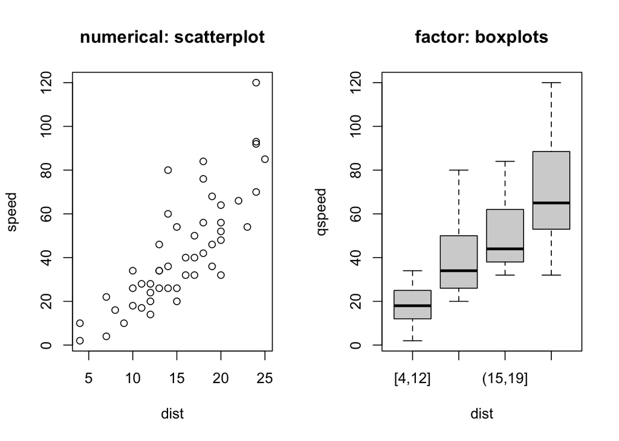

```r
cars$qspeed <- cut(cars$speed, breaks = quantile(cars$speed), include.lowest = TRUE) # cut divides the range of speed into intervals, codes the values in x according to which interval they fall

par(mfrow=c(1,2)) # Set the plotting area into a 1 by 2 array
plot(dist~speed,data = cars, main="numerical: scatterplot",
    xlab="dist", ylab="speed")
boxplot(dist~qspeed,data=cars, main="factor: boxplots",
   xlab="dist", ylab="qspeed")
```

***

### `Spatial` Objects

- Spatial-class: An abstract class from which useful spatial classes are derived
- CRS-class: Class “CRS” of coordinate reference system arguments

```r
library(sp)
getClass("Spatial")
```

```
## Class "Spatial" [package "sp"]
##
## Slots:
##
## Name:         bbox proj4string
## Class:      matrix         CRS
##
## Known Subclasses:
## Class "SpatialPoints", directly
## Class "SpatialMultiPoints", directly
## Class "SpatialGrid", directly
## Class "SpatialLines", directly
## Class "SpatialPolygons", directly
## Class "SpatialPointsDataFrame", by class "SpatialPoints", distance 2
## Class "SpatialPixels", by class "SpatialPoints", distance 2
## Class "SpatialMultiPointsDataFrame", by class "SpatialMultiPoints", distance 2
## Class "SpatialGridDataFrame", by class "SpatialGrid", distance 2
## Class "SpatialLinesDataFrame", by class "SpatialLines", distance 2
## Class "SpatialPixelsDataFrame", by class "SpatialPoints", distance 3
## Class "SpatialPolygonsDataFrame", by class "SpatialPolygons", distance 2
```

#### Constructing a Spatial Object

An R object of `Spatial` class must contain the following two slots:

- The first slot is called `bbox` and has to be a 2x2 matrix representing a bounding box. For example,
  $$bbox = \begin{pmatrix}
  1 & 2\\
  3 & 4
  \end{pmatrix}$$
  defines a box with range [1,2] on the x-axis and [3,4] on the y-axis.
- Can think of a bounding box as a rectangle such that all features of the spatial data must lie inside. Note: The column names **must be `c("min", "max")`**.
- The second slot is called `proj4string` and it contains a `CRS` (coordinate reference system) object. This information can be missing.

```r
## Set up the Bounding Box, m and Projection String, crs
m <- matrix(c(0,0,1,1), ncol=2, dimnames=list(NULL, c("min", "max")))
# recall that matrix entries are filled columnwise!
crs <- CRS(projargs=as.character(NA)) # stored as a character

S <- Spatial(bbox=m, proj4string=crs); S # Setting up a Spatial object
```

```
## An object of class "Spatial"
## Slot "bbox":
##      min max
## [1,]   0   1
## [2,]   0   1
##
## Slot "proj4string":
## Coordinate Reference System:
## Deprecated Proj.4 representation: NA
```

```r
str(S)
```

```
## Formal class 'Spatial' [package "sp"] with 2 slots
##   ..@ bbox       : num [1:2, 1:2] 0 0 1 1
##   .. ..- attr(*, "dimnames")=List of 2
##   .. .. ..$ : NULL
##   .. .. ..$ : chr [1:2] "min" "max"
##   ..@ proj4string:Formal class 'CRS' [package "sp"] with 1 slot
##   .. .. ..@ projargs: chr NA
```

- `sp` classes are S4 objects, so instead of having elements they have slots and you access them with `@`.

### `SpatialPoints`

- `SpatialPoints`: Class for (possibly irregularly-spaced) points
- Has slot `coords` for an $n \times 2$ matrix - each row contains (x,y)-coords for a single point
- Structure:

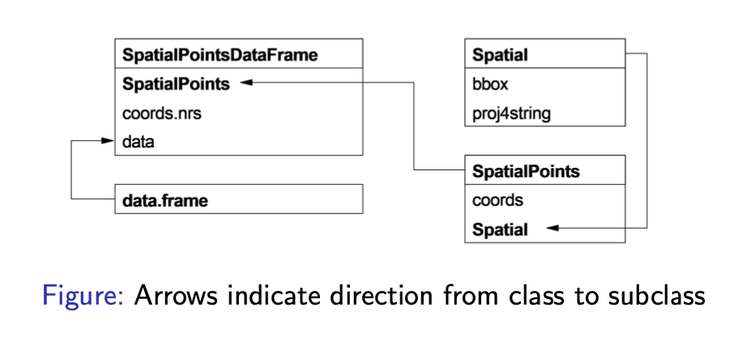

#### CRAN Mirrors Example

```r
CRAN_df <- read.table("CRAN051001a.txt", header=TRUE) # Loading CARN data.frame
CRAN_mat <- cbind(CRAN_df$long, CRAN_df$lat) # Initializing matrix of longitude and latitude
row.names(CRAN_mat) <- 1:nrow(CRAN_mat); nrow(CRAN_mat) # nrow() gives no. of points
```

```
## [1] 54
```

```r
llCRS <- CRS("+proj=longlat +ellps=WGS84")
```

```r
getClass("SpatialPoints")
```

```
## Class "SpatialPoints" [package "sp"]
##
## Slots:
##
## Name:       coords        bbox proj4string
## Class:      matrix      matrix         CRS
##
## Extends: "Spatial"
##
## Known Subclasses:
## Class "SpatialPointsDataFrame", directly
## Class "SpatialPixels", directly
## Class "SpatialPixelsDataFrame", by class "SpatialPixels", distance 2
```

```r
CRAN_sp <- SpatialPoints(CRAN_mat, proj4string=llCRS) # Initializing SpatialPoints object
summary(CRAN_sp); str(CRAN_sp)
```

```
## Object of class SpatialPoints
## Coordinates:
##                  min      max
## coords.x1 -122.95000 153.0333
## coords.x2  -37.81667  57.0500
## Is projected: FALSE
## proj4string : [+proj=longlat +ellps=WGS84 +no_defs]
## Number of points: 54
```

```
## Formal class 'SpatialPoints' [package "sp"] with 3 slots
##   ..@ coords     : num [1:54, 1:2] 153 145 16.3 -49.3 -42.9 ...
##   .. ..- attr(*, "dimnames")=List of 2
##   .. .. ..$ : chr [1:54] "1" "2" "3" "4" ...
##   .. .. ..$ : chr [1:2] "coords.x1" "coords.x2"
##   ..@ bbox       : num [1:2, 1:2] -123 -37.8 153 57
##   .. ..- attr(*, "dimnames")=List of 2
##   .. .. ..$ : chr [1:2] "coords.x1" "coords.x2"
##   .. .. ..$ : chr [1:2] "min" "max"
##   ..@ proj4string:Formal class 'CRS' [package "sp"] with 1 slot
##   .. .. ..@ projargs: chr "+proj=longlat +ellps=WGS84 +no_defs"
##   .. .. ..$ comment: chr "GEOGCRS[\"unknown\",\n    DATUM[\"Unknown based on WGS84 ellipsoid\",\n        ELLIPSOID[\"WGS 84\",6378137,298"| __truncated__
```

#### Plot of CRAN mirrors in Brazil

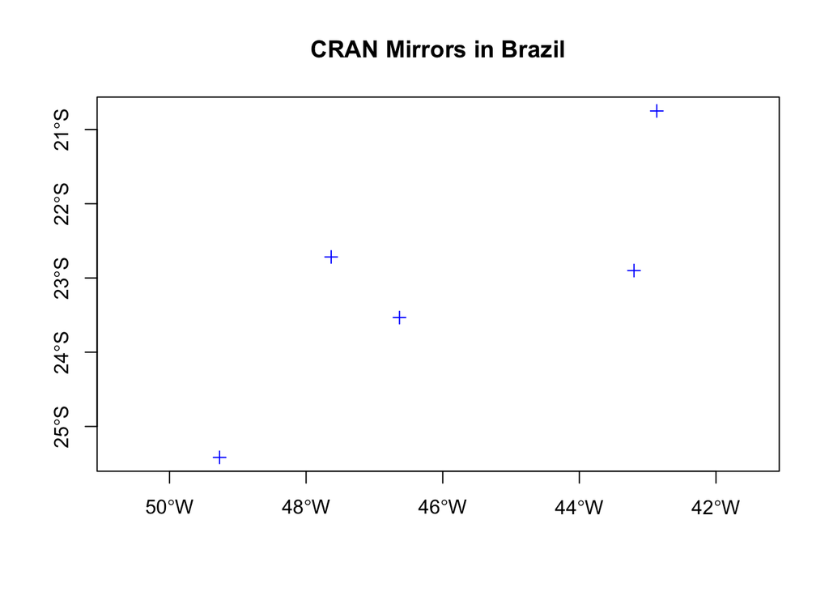

```r
# which() returns the indexes (positions) for which a Boolean vector returns TRUE
brazil <- which(CRAN_df$loc == "Brazil")
plot(CRAN_sp[brazil,], axes=TRUE, col='blue',main='CRAN Mirrors in Brazil')
```

#### `SpatialPointsDataFrame` - Adding Attributes

- `SpatialPointsDataFrame` is a subclass of `SpatialPoints` with two additional arguments: `data` (data frame) and `coords.nrs`.
- The argument `data` contains non-spatial information, for example the country in which the CRAN mirror site is located.
- We ignore the `coords.nrs` slot here.
- The next example shows how you can extend a spatial point object to a data frame.

```r
# When match.ID = TRUE, R checks if rows in spatial point object and data frame
## are matched according to their row names
CRAN_spdf1 <- SpatialPointsDataFrame(CRAN_mat, CRAN_df, proj4string=llCRS,
  match.ID=TRUE)
str(CRAN_spdf1, max.level=2)
```

```
## Formal class 'SpatialPointsDataFrame' [package "sp"] with 5 slots
##   ..@ data       :'data.frame':  54 obs. of  6 variables:
##   ..@ coords.nrs : num(0)
##   ..@ coords     : num [1:54, 1:2] 153 145 16.3 -49.3 -42.9 ...
##   .. ..- attr(*, "dimnames")=List of 2
##   ..@ bbox       : num [1:2, 1:2] -123 -37.8 153 57
##   .. ..- attr(*, "dimnames")=List of 2
##   ..@ proj4string:Formal class 'CRS' [package "sp"] with 1 slot
```

```r
# Treats CRAN_spdf like a data frame that merges coordinates with non-spatial information
Curitiba = CRAN_spdf1[4,]; Curitiba # Note this is still a `SpatialPointsDataFrame` object!
```

```
##              coordinates    place   north    east    loc      long       lat
## 4 (-49.26667, -25.41667) Curitiba 25d25'S 49d16'W Brazil -49.26667 -25.41667
```

```r
# Accessing the Curitiba Object:
Curitiba$place # Can either access it like a traditional data frame
```

```
## [1] "Curitiba"
```

```r
Curitiba@coords # Or you can access its slots
```

```
##   coords.x1 coords.x2
## 4 -49.26667 -25.41667
```

```r
# Extracting a specific column in the data frame (from the `data` slot)
str(CRAN_spdf1[["loc"]]) # Or equivalently, call `CRAN_spdf1$loc`
```

```
##  chr [1:54] "Australia" "Australia" "Austria" "Brazil" "Brazil" "Brazil" ...
```

### `SpatialLines`

- `SpatialLines` is a subclass of `Spatial`
- In addition to the data attributes `bbox` and `proj4string` from `Spatial` class, contains an additional attribute `lines`, contains information on one or more lines.
  - At the lowest layer, a `Line` object is an $n \times 2$ coordinate matrix. R connects the first point to the second point, and up to the nth point to create a line.
  - A `Lines` object is a list of one or more `Line` objects, plus an ID slot. Allows to put multiple lines within a single identification.
  - e.g. Representing MRT tracks in Singapore using `SpatialLines` object: `lines` slot can be a list with `Lines` objects `East-West`, `North-South`, `Downtown` etc.

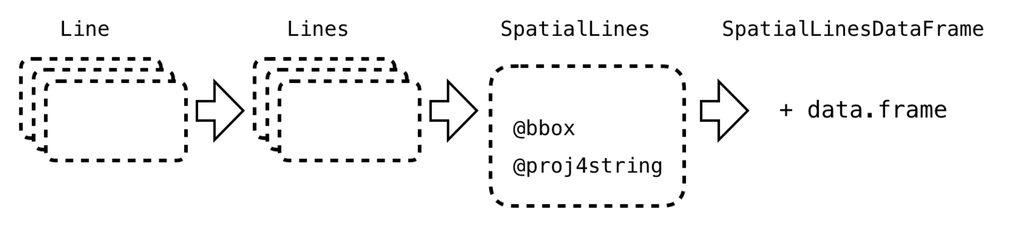

```r
# Create the coordinates:
A_coords <- matrix(c(0,4,2,2), nrow=2, byrow=TRUE)
B_coords <- matrix(c(3,2,3,0), nrow=2, byrow=TRUE)
C_coords <- matrix(c(1,0,1,2), nrow=2, byrow=TRUE)
D_coords <- matrix(c(0,1,2,1), nrow=2, byrow=TRUE)

# Create the Line objects: (Lowest Layer)
# Line(<n x 2 coord matrix>) -- Every Line is a connection of points in the matrix
Line_A <- Line(A_coords); Line_B <- Line(B_coords)
Line_C <- Line(C_coords); Line_D <- Line(D_coords)

# Create the Lines objects: (Think of this as a SET of Line objects -- list of Line's)
# Lines(<list>,<ID_character string>)
Lines1 <- Lines(list(Line_A, Line_B), "AB") # Each Lines object has to be represented by an ID!
Lines2 <- Lines(list(Line_C, Line_D), "CD")

# Create the SpatialLines object
# SpatialLines(<list>) -> list of Lines objects
SL <- SpatialLines(list(Lines1, Lines2))
```

#### Plot of SL

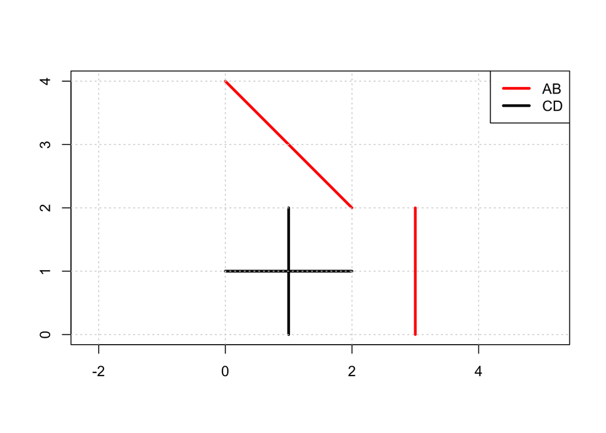

```r
plot(SL, col=c("red", "black"), lwd=3, axes=TRUE) # lwd represents line width
grid()
legend("topright", lwd=3, lty=1, col=c("red", "black"),
       legend=c("AB", "CD")) # lty,lwd (one of these two must be specified for line drawing)
```

#### Extend a spatial lines to a data frame

- `SpatialLinesDataFrame` is a subclass of `SpatialLines` with an additional `data` (data frame) attribute.
- Each row of the data frame contains the attributes of a `Lines` object in your spatial lines data frame.
- Both `sapply` and `lapply` can be applied to extract common information for each Lines object including its attributes.

```r
df <- data.frame(bumps=c(5.6, 10.2))
row.names(df) <- c("CD", "AB")
# Match the ID to the input data frame for the `SpatialLines` object
SLDF <- SpatialLinesDataFrame(SL, df, match.ID=TRUE)

slot(SLDF, "data") # To access the data slot, either call the slot function
```

```
##    bumps
## AB  10.2
## CD   5.6
```

```r
# Equivalently: use SLDF@data
```

#### Extracting information using `sapply`

- Suppose `SLjapan` is a `SpatialLines` with 34 `Lines` objects.
- Each `Lines` object contain one or more `Line` object.

```r
# Initialization of data
library(maps); library(maptools)
japan <- map("world", "japan", plot=FALSE)
p4s <- CRS("+proj=longlat +ellps=WGS84")
SLjapan <- map2SpatialLines(japan, proj4string=p4s)

# To determine the no. of `Line` objects in each `Lines` object
# slot(SLjapan, "lines") accesses the `lines` slot (which is a List of 34 objects)

num_obj=function(x){ # For ea. element in this list
    length(slot(x,"Lines")) # access the `Lines` slot (List of `Line` objects)
} # Want to know the length of this list!

l_lengths <- sapply(slot(SLjapan, "lines"), num_obj)
head(l_lengths)
```

```
## [1] 1 1 1 1 1 1
```